# Analysis of Covariance (ANCOVA) in R

- Show All Code
- Hide All Code
- View Source

Two Worked Examples for Agricultural Experiments — AGST 50104

Author

Dr. Samuel B Fernandes

Published

January 1, 2026

```r
# ── Package loading ──────────────────────────────────────────────────────────
# Data wrangling
library(dplyr)
library(tidyr)

# Visualization
library(ggplot2)

# Statistics: Type III SS, Levene's test
library(car)

# Adjusted means and pairwise comparisons
library(emmeans)

# Tidy model output
library(broom)
library(knitr)

# Reproducibility seed set globally
set.seed(50104)
```

# 1 Background: Covariates in Designed Experiments

## 1.1 What is a covariate?

In a designed experiment, you often measure variables beyond the primary response. A **covariate** is any measurable characteristic of an experimental unit that:

- is believed to affect the response variable,
- is **not** the treatment of interest, and
- ideally is recorded **before** treatments are applied.

Common examples in agricultural research include:

| Experiment type | Covariate | Primary response |
| --- | --- | --- |
| Herbicide trial | Pre-treatment weed density (plants/m²) | Post-treatment weed cover |
| Fertilizer trial | Baseline soil organic matter (%) | Grain yield |
| Cover crop study | Fall soil moisture | Spring emergence |
| Animal feeding | Initial body weight | Weight gain |

## 1.2 Why does ANCOVA matter?

Even with proper randomization, experimental units will never start in exactly identical condition. Some plots may have more weeds; some animals may start heavier. When that pre-existing variation is related to the outcome you measure, it inflates the unexplained error in your analysis—making it harder to detect real treatment differences.

**Analysis of Covariance (ANCOVA)** solves this by statistically “leveling the playing field.” It combines the treatment-comparison logic of ANOVA with the adjustment power of regression. The result: treatment means are compared *after* removing the portion of variability explained by the covariate.

The practical payoff is threefold:

1. **Reduced error variance** — the residual mean square (MSE) gets smaller,
2. **More precise treatment estimates** — narrower confidence intervals,
3. **Greater power** — real differences are easier to detect.

## 1.3 The key modeling idea

Think of ANCOVA this way. In a simple one-way ANOVA, we ask:

> “Do treatment groups differ on average?”

ANCOVA asks a sharper question:

> “Do treatment groups differ on average *after accounting for the fact that they started at different covariate levels?*”

To do that, the model includes both a categorical treatment factor and a continuous covariate as predictors. The treatment comparison is then made at a *common, shared covariate value* — usually the overall mean.

## 1.4 Three practical cautions

**CautionCaution 1 — Measure the covariate before treatment (i.e, the covariate is not significantly affected by treatment)**

A covariate only makes sense as a correction for pre-existing differences if treatment could not possibly have changed it. Pre-treatment weed density is a valid covariate for a herbicide trial; post-treatment weed density is not — the herbicide may have already reduced it. Always think about timing.

**WarningCaution 2 — Check the treatment-by-covariate interaction (Interaction must not be significant!)**

Standard ANCOVA assumes all treatment groups share a single common slope relating the covariate to the response (the “parallel lines” assumption). If this assumption fails — that is, if the relationship between covariate and response differs by treatment — then one adjusted mean per treatment is no longer meaningful. Always test the interaction before trusting the adjusted means. DROP THE COVARIATE IF THE INTERACTION IS SIGNIFICANT!

**NoteCaution 3 — Adjustment only helps when assumptions are reasonable (Linear Relationship)**

ANCOVA improves precision when (a) the covariate is linearly related to the response, (b) the covariate is not systematically different across treatment groups, and (c) the parallel-slopes assumption holds. If any of these conditions fail badly, the adjustment may introduce more problems than it solves.

# 2 ANCOVA: The Statistical Model

## 2.1 Model equation

For a completely randomized design with one covariate, the ANCOVA model is:

$$y_{ij} = \mu + \alpha_i + \beta \,(x_{ij} - \bar{x}) + \varepsilon_{ij}$$

| Symbol | Meaning |
| --- | --- |
| $y_{ij}$ | Response for treatment $i$, replicate $j$ |
| $\mu$ | Overall intercept (grand mean at $\bar{x}$) |
| $\alpha_i$ | Effect of treatment $i$ ($i = 1, \ldots, t$) |
| $\beta$ | Common slope — how much $y$ changes per unit increase in $x$ |
| $x_{ij}$ | Covariate value for treatment $i$, replicate $j$ |
| $\bar{x}$ | Grand mean of the covariate |
| $\varepsilon_{ij}$ | Random error, assumed $\sim \mathcal{N}(0,\,\sigma^2)$ |

Centering the covariate at $\bar{x}$ (subtracting the grand mean) makes the intercept $\mu$ directly interpretable as the adjusted grand mean, but has no effect on inference.

## 2.2 Assumptions checklist

Before fitting an ANCOVA model, verify each of the following:

1. **Covariate independence from treatment** — the covariate should not systematically vary across treatment groups. Check with a one-way ANOVA where the covariate is the response.
2. **Linear covariate–response relationship** — a scatterplot of $y$ vs. $x$ should show a straight-line pattern (within each treatment group).
3. **Homogeneity of regression slopes** — the slope $\beta$ should be similar across all treatment groups. Test this with a treatment × covariate interaction model.
4. ANOVA assumptions **Normally distributed, constant-variance residuals, Independent Residuals** — standard linear model diagnostics apply.

# 3 Tutorial 1 — Herbicide Efficacy with Pre-Treatment Weed Density as Covariate

## 3.1 Study context

A weed scientist is evaluating three post-emergence herbicide treatments (Control, Herbicide A, Herbicide B) for suppressing broadleaf weeds in soybean. Thirty plots are randomized to the three treatments (10 plots each). Before spraying, the pre-treatment weed density (plants/m²) is recorded on each plot. After four weeks, the percentage of weed cover remaining is measured.

**Research question:** Do the herbicide treatments reduce weed cover differently, after adjusting for the fact that plots started with different initial weed densities?

## 3.2 Simulate the dataset

```r
# Simulate 30 plots: 10 per herbicide treatment
data_herb <- tibble(
  plot = 1:30,
  treatment = factor(
    rep(c("Control", "Herb_A", "Herb_B"), each = 10),
    levels = c("Control", "Herb_A", "Herb_B")
  ),
  # Pre-treatment weed density (plants/m²), similar across treatments
  weed_density_pre = c(
    runif(10, 18, 42),   # Control
    runif(10, 16, 44),   # Herb A
    runif(10, 17, 43)    # Herb B
  )
) |>
  mutate(
    # True treatment effects on % weed cover after spraying
    trt_effect = case_when(
      treatment == "Control" ~ 0,
      treatment == "Herb_A"  ~ -28,
      treatment == "Herb_B"  ~ -38
    ),
    # Weed cover is positively related to pre-treatment density + treatment + noise
    weed_cover_pct = pmax(
      0,
      55 + trt_effect + 0.55 * (weed_density_pre - mean(weed_density_pre)) +
        rnorm(n(), sd = 7)
    )
  )

# Summary table
data_herb |>
  group_by(treatment) |>
  summarise(
    n        = n(),
    mean_pre = round(mean(weed_density_pre), 1),
    sd_pre   = round(sd(weed_density_pre), 1),
    mean_cov = round(mean(weed_cover_pct), 1),
    sd_cov   = round(sd(weed_cover_pct), 1),
    .groups  = "drop"
  ) |>
  kable(
    col.names = c("Treatment", "n",
                  "Mean pre-density (pl/m²)", "SD",
                  "Mean % cover", "SD"),
    caption = "Table 1. Summary of simulated herbicide trial data."
  )
```

Table 1. Summary of simulated herbicide trial data.

| Treatment | n | Mean pre-density (pl/m²) | SD | Mean % cover | SD |
| --- | --- | --- | --- | --- | --- |
| Control | 10 | 33.1 | 7.1 | 59.1 | 11.8 |
| Herb_A | 10 | 33.1 | 9.4 | 27.7 | 8.1 |
| Herb_B | 10 | 27.1 | 6.0 | 12.4 | 7.5 |

Notice that mean pre-treatment densities are roughly similar across groups — this is what we want to confirm statistically.

## 3.3 Step 1 — Verify covariate independence from treatment

Run a one-way ANOVA with **pre-treatment weed density as the response** and treatment as the predictor. A non-significant result supports the assumption that the covariate is not confounded with treatment.

```r
model_cov_check <- lm(weed_density_pre ~ treatment, data = data_herb)
Anova(model_cov_check, type = "III") |>
  tidy() |>
  kable(digits = 3,
        caption = "Table 2. ANOVA of pre-treatment weed density by treatment.")
```

Table 2. ANOVA of pre-treatment weed density by treatment.

| term | sumsq | df | statistic | p.value |
| --- | --- | --- | --- | --- |
| (Intercept) | 10978.851 | 1 | 187.228 | 0.000 |
| treatment | 240.870 | 2 | 2.054 | 0.148 |
| Residuals | 1583.254 | 27 | NA | NA |

A non-significant p-value here confirms that the covariate (pre-treatment density) is independent of treatment assignment — a key prerequisite for ANCOVA.

## 3.4 Step 2 — Visualize the covariate–response relationship

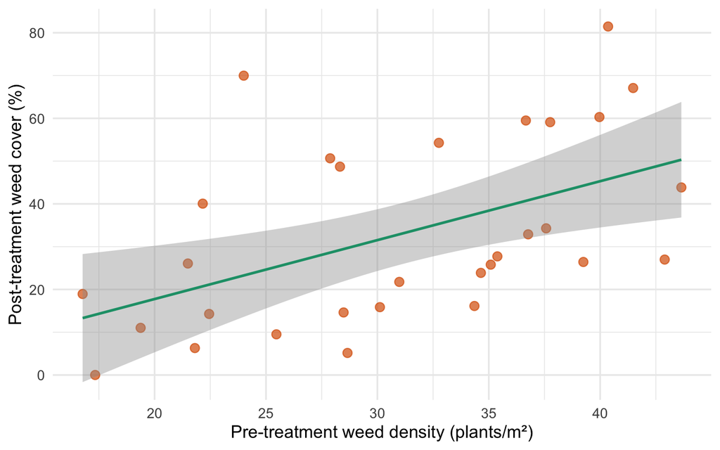

Figure 1: Figure 1. Relationship between pre-treatment weed density and post-treatment weed cover. The positive slope suggests adjusting for initial density will improve precision.

```r
ggplot(data_herb, aes(x = weed_density_pre, y = weed_cover_pct)) +
  geom_point(size = 3, alpha = 0.7, color = "#d95f02") +
  geom_smooth(method = "lm", se = TRUE, color = "#1b9e77", linewidth = 1) +
  labs(
    x = "Pre-treatment weed density (plants/m²)",
    y = "Post-treatment weed cover (%)"
  ) +
  theme_minimal(base_size = 14)
```

The upward slope confirms that plots with higher initial weed pressure tend to retain more cover after treatment — exactly the kind of relationship that ANCOVA exploits.

## 3.5 Step 3 — Check parallel slopes (homogeneity of regression)

Plot the covariate–response relationship separately for each treatment group. Roughly parallel lines support the use of a single common slope in the ANCOVA model.

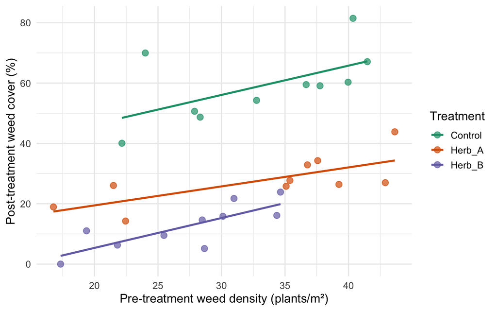

Figure 2: Figure 2. Treatment-specific regression lines. Roughly parallel lines support the standard ANCOVA assumption.

```r
ggplot(data_herb, aes(x = weed_density_pre, y = weed_cover_pct,
                       color = treatment)) +
  geom_point(size = 3, alpha = 0.7) +
  geom_smooth(method = "lm", se = FALSE, linewidth = 1.1) +
  scale_color_brewer(palette = "Dark2") +
  labs(
    x     = "Pre-treatment weed density (plants/m²)",
    y     = "Post-treatment weed cover (%)",
    color = "Treatment"
  ) +
  theme_minimal(base_size = 14)
```

## 3.6 Step 4 — Formally test the interaction

Fit the interaction model and test whether the treatment × covariate interaction is significant.

```r
model_interaction <- lm(weed_cover_pct ~ treatment * weed_density_pre,
                        data = data_herb)
Anova(model_interaction, type = "III") |>
  tidy() |>
  kable(digits = 3,
        caption = "Table 3. ANOVA table for ANCOVA with treatment × covariate interaction.")
```

Table 3. ANOVA table for ANCOVA with treatment × covariate interaction.

| term | sumsq | df | statistic | p.value |
| --- | --- | --- | --- | --- |
| (Intercept) | 290.198 | 1 | 5.431 | 0.029 |
| treatment | 352.257 | 2 | 3.296 | 0.054 |
| weed_density_pre | 430.663 | 1 | 8.059 | 0.009 |
| treatment:weed_density_pre | 48.397 | 2 | 0.453 | 0.641 |
| Residuals | 1282.495 | 24 | NA | NA |

**Important**

If the `treatment:weed_density_pre` interaction is significant (p < 0.05), **stop here** and interpret the interaction model directly — the slopes differ by treatment, so one adjusted mean per treatment is not appropriate.

If the interaction is **not significant**, proceed to the simpler ANCOVA below.

## 3.7 Step 5 — Fit the main ANCOVA model (parallel slopes)

```r
model_ancova <- lm(weed_cover_pct ~ treatment + weed_density_pre,
                   data = data_herb)

Anova(model_ancova, type = "III") |>
  tidy() |>
  kable(digits = 3,
        caption = "Table 4. ANCOVA table (Type III SS) — treatment effect adjusted for pre-treatment density.")
```

Table 4. ANCOVA table (Type III SS) — treatment effect adjusted for pre-treatment density.

| term | sumsq | df | statistic | p.value |
| --- | --- | --- | --- | --- |
| (Intercept) | 1334.150 | 1 | 26.064 | 0 |
| treatment | 8889.288 | 2 | 86.830 | 0 |
| weed_density_pre | 1018.492 | 1 | 19.897 | 0 |
| Residuals | 1330.892 | 26 | NA | NA |

The treatment row tests whether the three herbicide groups differ in weed cover **after** statistically removing the influence of pre-treatment density.

## 3.8 Step 6 — Estimate and compare adjusted means

Adjusted means are treatment means evaluated at the **grand mean covariate value** — that is, at the average pre-treatment weed density across all plots. This puts all treatments on the same footing for comparison.

```r
adj_means <- emmeans(
  model_ancova, ~ treatment,
  at = list(weed_density_pre = mean(data_herb$weed_density_pre))
)

summary(adj_means, infer = c(TRUE, TRUE)) |>
  as.data.frame() |>
  select(treatment, emmean, lower.CL, upper.CL) |>
  kable(digits = 2,
        col.names = c("Treatment", "Adjusted mean % cover", "Lower 95% CL", "Upper 95% CL"),
        caption = "Table 5. Adjusted treatment means from ANCOVA (evaluated at grand mean weed density).")
```

Table 5. Adjusted treatment means from ANCOVA (evaluated at grand mean weed density).

| Treatment | Adjusted mean % cover | Lower 95% CL | Upper 95% CL |
| --- | --- | --- | --- |
| Control | 57.50 | 52.79 | 62.21 |
| Herb_A | 26.12 | 21.41 | 30.82 |
| Herb_B | 15.64 | 10.75 | 20.52 |

```r
pairs(adj_means, adjust = "tukey") |>
  as.data.frame() |>
  select(contrast, estimate, SE, t.ratio, p.value) |>
  kable(digits = 3,
        caption = "Table 6. Tukey pairwise comparisons of adjusted means.")
```

Table 6. Tukey pairwise comparisons of adjusted means.

| contrast | estimate | SE | t.ratio | p.value |
| --- | --- | --- | --- | --- |
| Control - Herb_A | 31.387 | 3.200 | 9.810 | 0.000 |
| Control - Herb_B | 41.868 | 3.377 | 12.397 | 0.000 |
| Herb_A - Herb_B | 10.480 | 3.377 | 3.103 | 0.012 |

## 3.9 Step 7 — Compare adjusted vs. unadjusted means

```r
unadj <- data_herb |>
  group_by(treatment) |>
  summarise(unadjusted = round(mean(weed_cover_pct), 2), .groups = "drop")

adj_df <- summary(adj_means) |>
  as.data.frame() |>
  transmute(treatment, adjusted = round(emmean, 2))

left_join(unadj, adj_df, by = "treatment") |>
  kable(
    col.names = c("Treatment", "Unadjusted mean (%)", "ANCOVA adjusted mean (%)"),
    caption   = "Table 7. Comparison of unadjusted ANOVA means versus ANCOVA adjusted means."
  )
```

Table 1: Table 7. Comparison of unadjusted ANOVA means versus ANCOVA adjusted means.

| Treatment | Unadjusted mean (%) | ANCOVA adjusted mean (%) |
| --- | --- | --- |
| Control | 59.11 | 57.50 |
| Herb_A | 27.72 | 26.12 |
| Herb_B | 12.42 | 15.64 |

When pre-treatment conditions differ randomly across groups, ANCOVA adjusts means upward or downward depending on whether a group happened to start at a covariate value above or below the grand mean.

## 3.10 Step 8 — Visualize adjusted means with confidence intervals

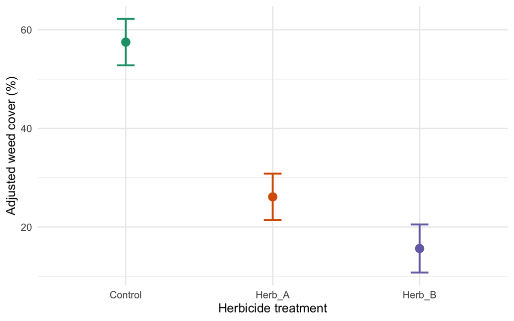

```r
adj_plot <- summary(adj_means) |> as.data.frame()

ggplot(adj_plot, aes(x = treatment, y = emmean, color = treatment)) +
  geom_point(size = 4) +
  geom_errorbar(aes(ymin = lower.CL, ymax = upper.CL),
                width = 0.12, linewidth = 1) +
  scale_color_brewer(palette = "Dark2") +
  labs(
    x     = "Herbicide treatment",
    y     = "Adjusted weed cover (%)",
    color = NULL
  ) +
  theme_minimal(base_size = 14) +
  theme(legend.position = "none")
```

## 3.11 Residual diagnostics

Standard linear model checks still apply to ANCOVA.

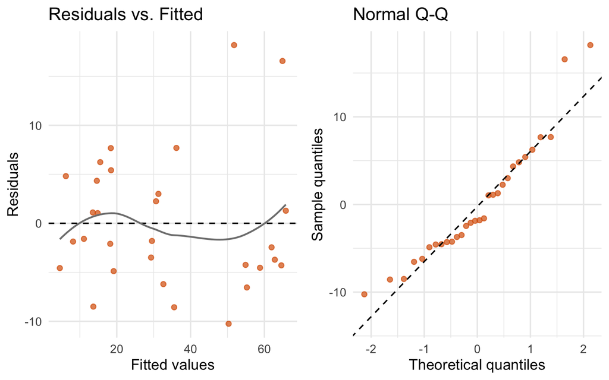

Figure 4: Figure 4. Residual diagnostics for the ANCOVA model. Left: residuals vs. fitted values (check for non-linearity or heteroskedasticity). Right: Q-Q plot (check for normality).

```r
augment(model_ancova) |>
  ggplot(aes(x = .fitted, y = .resid)) +
  geom_point(alpha = 0.7, color = "#d95f02") +
  geom_hline(yintercept = 0, linetype = "dashed") +
  geom_smooth(method = "loess", se = FALSE, color = "grey50", linewidth = 0.8) +
  labs(x = "Fitted values", y = "Residuals",
       title = "Residuals vs. Fitted") +
  theme_minimal(base_size = 14) -> p1

augment(model_ancova) |>
  ggplot(aes(sample = .resid)) +
  stat_qq(color = "#d95f02", alpha = 0.7) +
  stat_qq_line(linetype = "dashed") +
  labs(x = "Theoretical quantiles", y = "Sample quantiles",
       title = "Normal Q-Q") +
  theme_minimal(base_size = 14) -> p2

gridExtra::grid.arrange(p1, p2, ncol = 2)
```

**What to look for:**

- **Residuals vs. Fitted**: points should scatter randomly around zero — no funnel shape (heteroskedasticity) and no curve (nonlinearity).
- **Q-Q plot**: points should follow the diagonal line — major deviations suggest non-normality.

# 4 Tutorial 2 — Weed Control Intensity and Crop-Weed Competition

*Inspired by examples from:*  
*Ritz & Streibig — “Statistical Analysis of Agricultural Experiments using R”*  
*(https://rstats4ag.org/analysis-of-covariance-ancova.html)*

## 4.1 Example 2a — Mechanical weed control: does harrowing intensity matter?

### 4.1.1 Study context

This is ANCOVA used as a **model-comparison tool** — starting from the most general model (ANOVA, no assumed shape) and simplifying toward the most parsimonious description of the data.

### 4.1.2 Load and explore the data

```r
# Load directly from the rstats4ag repository
harrowing_url <- "http://rstats4ag.org/data/Harrowing.csv"
harrowing <- tryCatch(
  read.csv2(harrowing_url),
  error = function(e) NULL
)

# Fallback: simulate representative data if the URL is unavailable
if (is.null(harrowing)) {
  set.seed(50104)
  harrowing <- expand.grid(
    int       = 0:4,
    direction = c("along", "across"),
    rep       = 1:4
  ) |>
    as_tibble() |>
    mutate(
      Log.weeds = 5.04 - 1.11 * int + rnorm(n(), sd = 0.35),
      weeds     = exp(Log.weeds)
    )
  message("Remote data unavailable — using simulated fallback data.")
} else {
  harrowing <- harrowing |>
    mutate(Log.weeds = log(weeds))
}

glimpse(harrowing)
```

```
#> Rows: 40
#> Columns: 7
#> $ plot      <int> 1, 2, 3, 4, 5, 6, 7, 8, 9, 10, 11, 12, 13, 14, 15, 16, 17, 1…
#> $ leaf      <dbl> 0.18623052, 0.12696533, 0.09006582, 0.07539630, 0.04011849, …
#> $ weeds     <dbl> 103.337631, 54.020217, 23.440347, 5.862066, 1.103108, 205.75…
#> $ int       <int> 0, 1, 2, 3, 4, 0, 1, 2, 3, 4, 0, 1, 2, 3, 4, 0, 1, 2, 3, 4, …
#> $ direction <chr> "along", "along", "along", "along", "along", "along", "along…
#> $ yield     <dbl> 4.21, 4.08, 3.92, 3.90, 3.68, 4.20, 4.10, 3.85, 3.84, 3.61, …
#> $ Log.weeds <dbl> 4.63800160, 3.98935836, 3.15445876, 1.76850204, 0.09813165, …
```

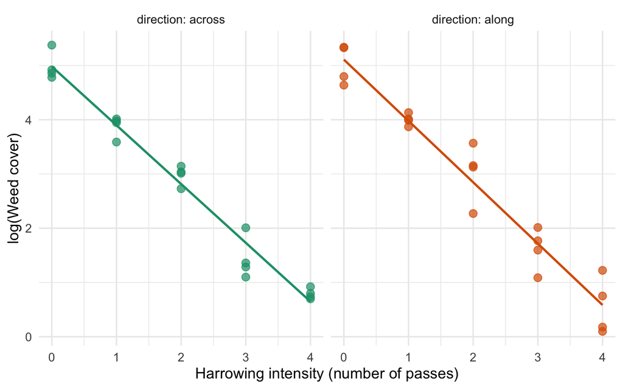

Figure 5: Figure 5. Log-transformed weed cover versus harrowing intensity, separated by direction. The linear pattern supports an ANCOVA approach.

```r
ggplot(harrowing, aes(x = int, y = Log.weeds, color = direction)) +
  geom_point(size = 3, alpha = 0.7) +
  geom_smooth(method = "lm", se = FALSE, linewidth = 1) +
  facet_wrap(~direction, labeller = label_both) +
  scale_color_brewer(palette = "Dark2") +
  labs(
    x     = "Harrowing intensity (number of passes)",
    y     = "log(Weed cover)",
    color = "Direction"
  ) +
  theme_minimal(base_size = 14) +
  theme(legend.position = "none")
```

The log transformation linearizes the response (weed cover tends to decline exponentially with more harrowing passes). The next step is to decide whether we need separate lines for each direction.

### 4.1.3 Sequential model comparison

The ANCOVA workflow here involves fitting increasingly simple models and testing whether each simplification is justified by the data.

```r
# M1: Most general — ANOVA (int as a factor, no assumed linear shape)
m1 <- lm(Log.weeds ~ factor(int) * direction, data = harrowing)

# M2: ANCOVA with interaction — linear in int, but different slopes by direction
m2 <- lm(Log.weeds ~ int * direction, data = harrowing)

# M3: ANCOVA without interaction — parallel slopes, different intercepts
m3 <- lm(Log.weeds ~ int + direction, data = harrowing)

# M4: Simplest — one line for both directions
m4 <- lm(Log.weeds ~ int, data = harrowing)
```

**Test 1 — Is the linear model adequate (lack-of-fit test)?**

```r
anova(m1, m2) |>
  tidy() |>
  kable(digits = 3,
        caption = "Table 8. Lack-of-fit test: is a linear model adequate?")
```

Table 8. Lack-of-fit test: is a linear model adequate?

| term | df.residual | rss | df | sumsq | statistic | p.value |
| --- | --- | --- | --- | --- | --- | --- |
| Log.weeds ~ factor(int) * direction | 30 | 3.535 | NA | NA | NA | NA |
| Log.weeds ~ int * direction | 36 | 4.275 | -6 | -0.74 | 1.047 | 0.415 |

A non-significant p-value means we cannot reject the linear model — a straight line fits the log(weed cover) vs. intensity relationship adequately.

**Test 2 — Are the slopes the same for both directions?**

```r
anova(m2, m3) |>
  tidy() |>
  kable(digits = 3,
        caption = "Table 9. Interaction test: do slopes differ by direction?")
```

Table 9. Interaction test: do slopes differ by direction?

| term | df.residual | rss | df | sumsq | statistic | p.value |
| --- | --- | --- | --- | --- | --- | --- |
| Log.weeds ~ int * direction | 36 | 4.275 | NA | NA | NA | NA |
| Log.weeds ~ int + direction | 37 | 4.321 | -1 | -0.045 | 0.381 | 0.541 |

**Test 3 — Does direction matter at all (same intercept too)?**

```r
anova(m4, m3) |>
  tidy() |>
  kable(digits = 3,
        caption = "Table 10. Test for direction effect: does direction shift the intercept?")
```

Table 10. Test for direction effect: does direction shift the intercept?

| term | df.residual | rss | df | sumsq | statistic | p.value |
| --- | --- | --- | --- | --- | --- | --- |
| Log.weeds ~ int | 38 | 4.331 | NA | NA | NA | NA |
| Log.weeds ~ int + direction | 37 | 4.321 | 1 | 0.01 | 0.089 | 0.768 |

### 4.1.4 Interpret the final model

```r
tidy(m4) |>
  kable(digits = 3,
        caption = "Table 11. Final model: log(weed cover) ~ harrowing intensity.")
```

Table 11. Final model: log(weed cover) ~ harrowing intensity.

| term | estimate | std.error | statistic | p.value |
| --- | --- | --- | --- | --- |
| (Intercept) | 5.045 | 0.092 | 54.564 | 0 |
| int | -1.107 | 0.038 | -29.331 | 0 |

**Interpretation:** Each additional harrowing pass reduces log(weed cover) by approximately 1.11 units. On the original scale, this corresponds to an exponential decay — each pass multiplies the remaining weed cover by roughly $e^{-1.11} \approx 0.33$, meaning harrowing removes about two-thirds of remaining cover per additional pass. Direction of harrowing (along vs. across rows) did not significantly influence efficacy.

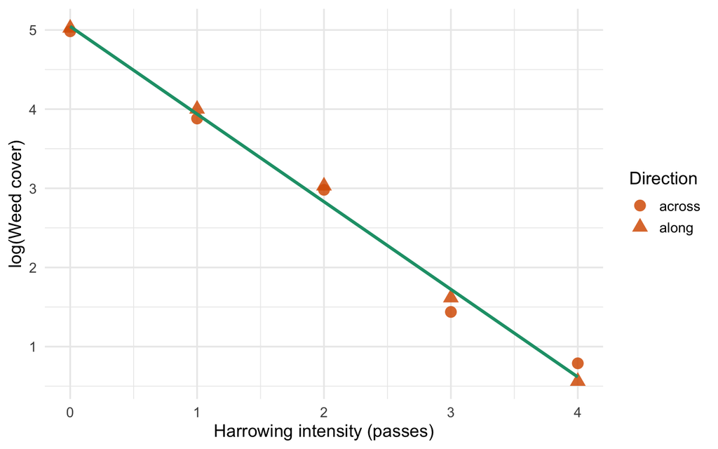

Figure 6: Figure 6. Final ANCOVA model: one regression line describes log(weed cover) across both directions. Points show group means; the line is the fitted model.

```r
plot_means_harr <- harrowing |>
  group_by(int, direction) |>
  summarise(Log.weeds = mean(Log.weeds), .groups = "drop")

pred_df <- tibble(int = seq(0, 4, length.out = 80)) |>
  mutate(fit = predict(m4, newdata = tibble(int = int)))

ggplot() +
  geom_point(data = plot_means_harr,
             aes(x = int, y = Log.weeds, shape = direction),
             size = 4, color = "#d95f02", alpha = 0.85) +
  geom_line(data = pred_df, aes(x = int, y = fit),
            color = "#1b9e77", linewidth = 1.2) +
  scale_shape_manual(values = c(16, 17)) +
  labs(
    x     = "Harrowing intensity (passes)",
    y     = "log(Weed cover)",
    shape = "Direction"
  ) +
  theme_minimal(base_size = 14)
```

## 4.2 Example 2b — Duration of weed competition and sugarbeet yield

### 4.2.1 Study context

Field studies measured the effect of *Salvia reflexa* (lanceleaf sage) interference on sugarbeet yield across two growing seasons (2006 and 2007). *Salvia reflexa* was established at constant density and allowed to compete for varying numbers of days after sugarbeet emergence. The central question:

> Is the relationship between competition duration and yield loss the same in both years, or does the year (a proxy for environmental conditions) shift the regression?

Here, “Year” acts as a second factor in an ANCOVA framework where competition duration is the continuous covariate (or predictor).

### 4.2.2 Load and explore the data

```r
sage_url <- "http://rstats4ag.org/data/lanceleafsage.csv"
lanceleaf <- tryCatch(
  read.csv(sage_url),
  error = function(e) NULL
)

# Fallback simulation if the URL is unavailable
if (is.null(lanceleaf)) {
  set.seed(50104)
  lanceleaf <- expand.grid(
    Replicate = 1:4,
    Duration  = c(36, 50, 64, 78, 92, 106, 120, 133),
    Year      = c(2006, 2007)
  ) |>
    as_tibble() |>
    mutate(
      base_yield   = if_else(Year == 2006, 72.1, 63.6),
      Yield_Mg.ha  = base_yield - 0.215 * Duration + rnorm(n(), sd = 7)
    )
  message("Remote data unavailable — using simulated fallback data.")
}

lanceleaf <- lanceleaf |>
  mutate(Year = factor(Year))

glimpse(lanceleaf)
```

```
#> Rows: 64
#> Columns: 5
#> $ Replicate      <int> 1, 1, 1, 1, 1, 1, 1, 2, 2, 2, 2, 2, 2, 2, 3, 3, 3, 3, 3…
#> $ Duration       <int> 36, 50, 64, 78, 92, 106, 0, 106, 92, 78, 64, 50, 36, 0,…
#> $ Year           <fct> 2006, 2006, 2006, 2006, 2006, 2006, 2006, 2006, 2006, 2…
#> $ Yield_Mg.ha    <dbl> 67.26, 60.34, 53.69, 52.54, 53.80, 60.69, 67.07, 33.01,…
#> $ Yield.loss.pct <dbl> 98.05, 87.96, 78.27, 76.59, 78.43, 88.47, 97.77, 48.12,…
```

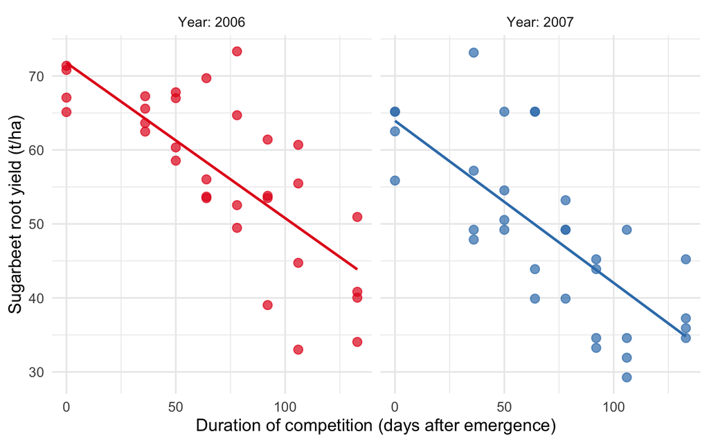

Figure 7: Figure 7. Sugarbeet yield versus duration of Salvia reflexa competition, by year. Lines show separate least-squares fits.

```r
ggplot(lanceleaf, aes(x = Duration, y = Yield_Mg.ha, color = Year)) +
  geom_point(size = 3, alpha = 0.7) +
  geom_smooth(method = "lm", se = FALSE, linewidth = 1) +
  facet_wrap(~Year, labeller = label_both) +
  scale_color_brewer(palette = "Set1") +
  labs(
    x     = "Duration of competition (days after emergence)",
    y     = "Sugarbeet root yield (t/ha)",
    color = "Year"
  ) +
  theme_minimal(base_size = 14) +
  theme(legend.position = "none")
```

Both years show a clear negative linear trend: longer weed competition reduces yield. The lines appear parallel but shifted vertically — 2007 yields are consistently lower, possibly due to environmental differences between seasons.

### 4.2.3 Sequential model comparison

```r
# LM1: Most general (ANOVA — Duration as a factor, no assumed shape)
lm1 <- lm(Yield_Mg.ha ~ factor(Duration) * Year, data = lanceleaf)

# LM2: ANCOVA with interaction — linear relationship, slopes may differ by year
lm2 <- lm(Yield_Mg.ha ~ Duration * Year, data = lanceleaf)

# LM3: Parallel slopes, different intercepts
lm3 <- lm(Yield_Mg.ha ~ Duration + Year, data = lanceleaf)

# LM4: Single regression line (year does not matter)
lm4 <- lm(Yield_Mg.ha ~ Duration, data = lanceleaf)
```

**Test 1 — Lack-of-fit: is a linear relationship adequate?**

```r
anova(lm1, lm2) |>
  tidy() |>
  kable(digits = 3,
        caption = "Table 12. Lack-of-fit test for the sugarbeet yield data.")
```

Table 12. Lack-of-fit test for the sugarbeet yield data.

| term | df.residual | rss | df | sumsq | statistic | p.value |
| --- | --- | --- | --- | --- | --- | --- |
| Yield_Mg.ha ~ factor(Duration) * Year | 48 | 3198.295 | NA | NA | NA | NA |
| Yield_Mg.ha ~ Duration * Year | 60 | 3667.074 | -12 | -468.778 | 0.586 | 0.842 |

**Test 2 — Do the slopes differ between years?**

```r
anova(lm2, lm3) |>
  tidy() |>
  kable(digits = 3,
        caption = "Table 13. Interaction test: do slopes differ by year?")
```

Table 13. Interaction test: do slopes differ by year?

| term | df.residual | rss | df | sumsq | statistic | p.value |
| --- | --- | --- | --- | --- | --- | --- |
| Yield_Mg.ha ~ Duration * Year | 60 | 3667.074 | NA | NA | NA | NA |
| Yield_Mg.ha ~ Duration + Year | 61 | 3669.110 | -1 | -2.037 | 0.033 | 0.856 |

**Test 3 — Does year affect the intercept (mean yield level)?**

```r
anova(lm4, lm3) |>
  tidy() |>
  kable(digits = 3,
        caption = "Table 14. Year effect: does year shift the yield intercept?")
```

Table 14. Year effect: does year shift the yield intercept?

| term | df.residual | rss | df | sumsq | statistic | p.value |
| --- | --- | --- | --- | --- | --- | --- |
| Yield_Mg.ha ~ Duration | 62 | 4819.338 | NA | NA | NA | NA |
| Yield_Mg.ha ~ Duration + Year | 61 | 3669.110 | 1 | 1150.227 | 19.123 | 0 |

### 4.2.4 Interpret the final model

```r
tidy(lm3) |>
  kable(digits = 3,
        caption = "Table 15. Final ANCOVA model: Yield ~ Duration + Year.")
```

Table 15. Final ANCOVA model: Yield ~ Duration + Year.

| term | estimate | std.error | statistic | p.value |
| --- | --- | --- | --- | --- |
| (Intercept) | 72.096 | 2.205 | 32.693 | 0 |
| Duration | -0.215 | 0.025 | -8.678 | 0 |
| Year2007 | -8.479 | 1.939 | -4.373 | 0 |

```r
glance(lm3) |>
  select(r.squared, adj.r.squared, sigma, AIC) |>
  kable(digits = 3,
        caption = "Table 16. Model fit statistics.")
```

Table 16. Model fit statistics.

| r.squared | adj.r.squared | sigma | AIC |
| --- | --- | --- | --- |
| 0.608 | 0.595 | 7.756 | 448.749 |

**Interpretation:**

- The slope for `Duration` (≈ −0.215 t/ha per day) is the same in both years: each additional day of *Salvia reflexa* competition reduces sugarbeet yield by about 0.21 t/ha, regardless of the growing season.
- The year intercept shift (≈ −8.5 t/ha in 2007) indicates that maximum potential yield was lower in 2007 than in 2006 — likely due to environmental variation between seasons, not the weed itself.
- The ANCOVA model (`lm3`) neatly separates these two sources of variation: the *biological* effect of competition duration (common to both years) and the *environmental* effect of year (an intercept shift).

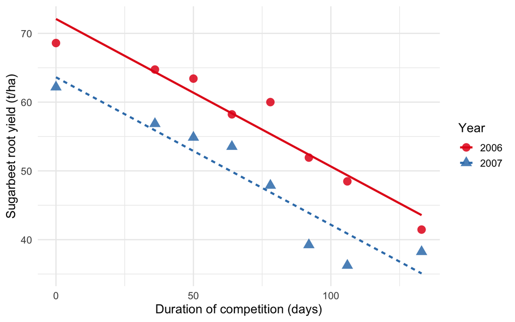

Figure 8: Figure 8. Final ANCOVA model: parallel regression lines for 2006 and 2007. The common slope (-0.215 t/ha/day) describes the yield cost of each additional day of weed competition.

```r
# Build prediction lines for each year
newdata_sage <- expand.grid(
  Duration = seq(min(lanceleaf$Duration), max(lanceleaf$Duration), length.out = 100),
  Year     = levels(lanceleaf$Year)
) |>
  as_tibble() |>
  mutate(fit = predict(lm3, newdata = cur_data()))

# Group means for plotting
means_sage <- lanceleaf |>
  group_by(Duration, Year) |>
  summarise(Yield_Mg.ha = mean(Yield_Mg.ha), .groups = "drop")

ggplot() +
  geom_point(data = means_sage,
             aes(x = Duration, y = Yield_Mg.ha, shape = Year, color = Year),
             size = 4, alpha = 0.85) +
  geom_line(data = newdata_sage,
            aes(x = Duration, y = fit, linetype = Year, color = Year),
            linewidth = 1.1) +
  scale_color_brewer(palette = "Set1") +
  labs(
    x     = "Duration of competition (days)",
    y     = "Sugarbeet root yield (t/ha)",
    color = "Year", shape = "Year", linetype = "Year"
  ) +
  theme_minimal(base_size = 14)
```

# 5 Diagnostics Reference

Regardless of which ANCOVA model you fit, always run these checks before reporting results.

## 5.1 What to check and how

| Diagnostic | How to check | What you hope to see |
| --- | --- | --- |
| Linearity | Residuals vs. fitted; scatterplot of $y$ vs. $x$ | Random scatter, no curve |
| Homogeneity of variance | Residuals vs. fitted, Levene’s test | Even spread across range |
| Normality | Q-Q plot, Shapiro-Wilk test | Points on diagonal; p > 0.05 |
| Homogeneity of slopes | Treatment × covariate interaction test | Non-significant interaction |
| Influential observations | Cook’s distance, leverage | No extreme outliers |

## 5.2 What to do if assumptions fail

- **Non-linearity**: try a log or square-root transformation of the response or covariate, or use a polynomial term.
- **Heterogeneity of variance**: weighted regression or variance-stabilizing transformation; consider `nlme::gls()` with a variance function.
- **Non-normality with large samples**: often minor; large-sample inference is robust. With small samples, consider a permutation approach.
- **Significant interaction**: do not use the simple parallel-slopes ANCOVA. Instead, report the interaction model, use `emmeans()` with `at = list(...)` to compare treatments at specific covariate values, or present separate regression summaries per treatment.

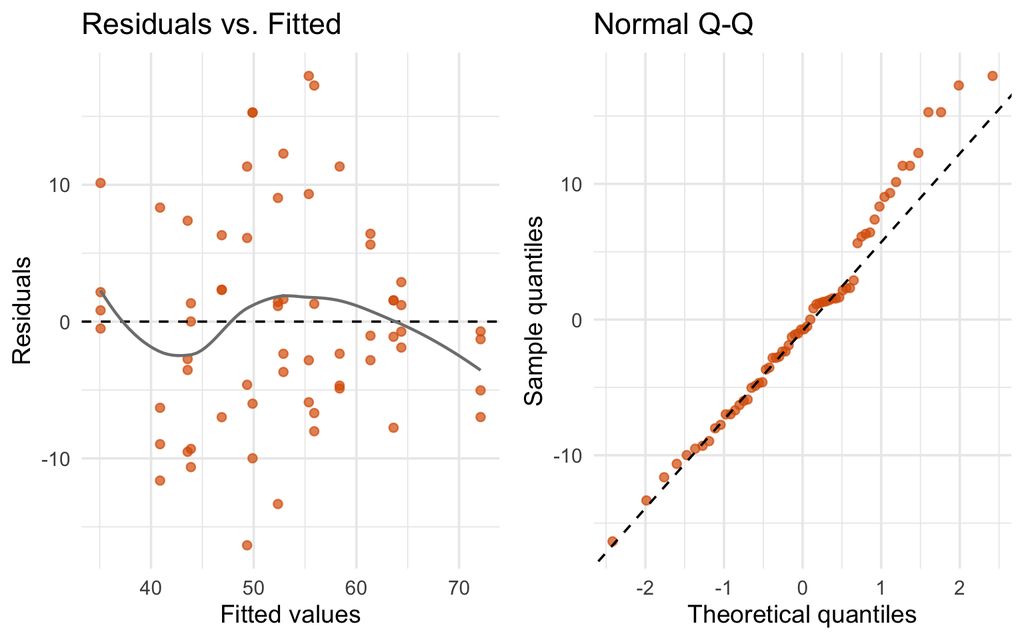

Figure 9: Figure 9. Residual diagnostics for the final sugarbeet ANCOVA model (lm3).

```r
augment(lm3) |>
  ggplot(aes(x = .fitted, y = .resid)) +
  geom_point(alpha = 0.7, color = "#d95f02") +
  geom_hline(yintercept = 0, linetype = "dashed") +
  geom_smooth(method = "loess", se = FALSE, color = "grey50", linewidth = 0.8) +
  labs(x = "Fitted values", y = "Residuals", title = "Residuals vs. Fitted") +
  theme_minimal(base_size = 14) -> p3

augment(lm3) |>
  ggplot(aes(sample = .resid)) +
  stat_qq(color = "#d95f02", alpha = 0.7) +
  stat_qq_line(linetype = "dashed") +
  labs(x = "Theoretical quantiles", y = "Sample quantiles", title = "Normal Q-Q") +
  theme_minimal(base_size = 14) -> p4

gridExtra::grid.arrange(p3, p4, ncol = 2)
```

# 6 Key Takeaways

**TipWhen is ANCOVA appropriate?**

Use ANCOVA when:

1. You have a quantitative variable measured **before** treatment that is expected to correlate with the response.
2. Blocking on that variable is impractical (it is continuous, or creating blocks would be costly).
3. The covariate is **not** affected by treatment.
4. The covariate–response relationship is approximately linear within each treatment group.
5. Regression slopes are similar across treatments (test this before proceeding).

**NoteAlways check first**

Before trusting adjusted means, verify:

1. **Covariate independence** — run ANOVA with the covariate as the response.
2. **Linearity** — scatterplot of $y$ vs. $x$.
3. **Parallel slopes** — plot treatment-specific lines; test the interaction formally.
4. **Residual assumptions** — normality and homogeneity of variance.

**ImportantHow to report ANCOVA results in practice**

A complete ANCOVA report should state:

- The covariate used and **when** it was measured (pre-treatment).
- Whether the covariate was independent of treatment (report the ANOVA test).
- Whether the parallel-slopes assumption held (report the interaction test).
- The common slope and its standard error.
- Adjusted treatment means (evaluated at the grand mean of the covariate).
- Pairwise comparisons with an appropriate multiplicity adjustment (e.g., Tukey).
- The reduction in MSE relative to a model without the covariate, as evidence of improved precision.